# FROM GRAPES AND PRUNES TO APPLES AND APPLES: USING MATCHED METHODS TO ESTIMATE OPTIMAL ZONE ENTRY DECISION-MAKING IN THE NATIONAL HOCKEY LEAGUE

Asmae Toumi https://twitter.com/asmae_toumi (Columbia University)https://www.columbia.edu , Michael Lopez https://statsbylopez.netlify.com (NFL)https://www.nfl.com  
2019-09-28

## Abstract

Previous research in the National Hockey League has suggested that teams’ decisions to gain the offensive zone with puck possession (“carry-ins”) is preferred over dumping the puck in and chasing after it (“dump-ins”). However, standard comparisons of zone entry strategy are confounded by factors such as offensive and defensive talent, location on the ice, and shift time, each of which impact player choice. Indeed, contrasting carry-ins to dump-ins isn’t exactly an apples-to-apples comparison; instead, it is more like studying grapes versus prunes. Using two matching methods – propensity score matching and Bayesian additive regression trees – we leverage player-tracking data to estimate the causal benefits due to zone-entry decisions. Both approaches better account for the variables that affect entry choice. We also highlight the wide-ranging potential of the causal inference framework with player tracking data in sports while emphasizing the challenges of using standard statistical methods to inform decision-making in the presence of substantial confounding.

This abstract was submitted to the 2019 New England Symposium of Statistics. It’s found in their program: http://nessis.org/program.pdf

## Introduction

In hockey, players can enter the offensive zone by either carrying the puck in or dumping it. This decision is typically made by the player or their head coach. This decision is informed by, among other factors, offensive and defensive talent, location on the ice, shift time, time left in the game and score differential.

Previous research done by Tulsky (2013) showed that:

> “A team that moves the puck through the neutral zone most effectively will be able to enter the offensive zone with possession, carrying the puck across the blue line. This might be expected to result in more shots and goals than a play where the team dumps the puck into the corner hoping to retrieve it. […] Every data set collected showed entries with possession being more than twice as effective as dump-ins at 5-on- 5. The neutral zone play that sets a team up to enter the offensive zone with possession is a critical driver of success.”

The primary goal of this research is to estimate the potential benefit that teams can gain by carrying it in instead of dumping it using a causal inference framework.

## The fundamental problem of causal inference

If the player knew the outcome of both zone entry strategies, deciding whether to carry the puck in or dump it would be a no-brainer. This is not possible, as we only know the outcome of *one* of the strategies, i.e. the one that the player chose. This is the problem that causal inference attempts to solve. Causal inference deals with prediciting the outcomes for the other strategy that was not undertaken. It also mimics some of the advantages of a randomized experiment when randomization is difficult or impossible to implement, like it is in hockey.

## Propensity score matching and BART

Given that carrying it in is considered the most efficient zone strategy, it’s important to estimate its causal benefit among the group who carried it in. To do so, we selected the *Average Treatment Effect on Treated* (ATT) as the estimand. ATT reflects the expected causal effect of carry-ins among players who did carry it in. In other words, it approximates the value of carry it in among those who had the chance to do so. The “treated” in our experiment is the group of players who carried the puck in and the control are those that dumped it in. To estimate the ATT, we used two approaches: propensity score matching and Bayesian Additive Regression Trees (BART):

### Propensity score matching

We use matched methods with finite population propensity scores (Imbens and Rubin, 2015) to help account for all the variables that could impact a player’s decision to carry the puck in or dump it. Propensity score, first introduced in 1983, corresponds to the probability of receiving a treatment given the observed variables (Rosenbaum and Rubin, 1983). The propensity score is used for flexible matching of treatment and control groups with similar distribution of variables. Grouping individuals with similar propensity scores works to replicate a randomized experiment (Stuart, 2010).

### Bayesian Additive Regression Trees (BART)

Another method used to estimate causal effects are Bayesian Additive Regression Trees (BART). BART is a Bayesian nonparametric modeling procedure that is used to fit the response surface model (Hill, 2012). Compared to propensity score matching, BART generates posterior intervals. Additionally, treatment effect estimates using BART have been shown to be signficiantly more accurate than propensity score matching. It is also believed to be the more superior approach when there are many confounding covariates as is the case in many causal inference problems. Finally, BART also has the advantage of readily identifying heterogeneous treatment effects which is of special interest to us.

## Data

We obtained zone-entry tracking data from Stathletes for the 2017-18 and 2018-19 NHL seasons. We matched only within even-strength situations, leaving `n = 277,661` entries, of which `n = 158,808` were carry-ins and `n = 118,853` were dump-ins. We obtained Goals Plus-Minus per 60 minutes (`GPM_60`) from Evolving-Hockey in order to account for player skill. From Evolving-Hockey, we also obtained expected goals (`xG`) and calculated xG as a function of time using NHL play-by-play data.

## Propensity score model

Our propensity score model estimates the probability of a player carrying the puck in given game characteristics of each carry-in. This probability is called $e(X)$. We used a multiple logistic regression model with spline terms to estimate the covariates defined in Table 1 below. The ultimate goal of estimating $e(X)$ is to balance the variables in X between the players that carried it in and the players that did not. The full list of interaction terms and spline knots used in the propensity score model can also be found in Table 1. Note: the list of interaction terms were chosen using our understanding of what influences zone entry decision-making. The spline knots were optimized to obtain the lowest Akaike Information Criterion (AIC).

**Table 1: Descriptions of variables and interaction terms used in the propensity score model**

| Variable | Description | Spline knots |
| --- | --- | --- |
| Position | position of entry player, forward or defenseman | NA |
| score_diff | score differential | NA |
| length_of_shift | shift length for entry player | 10 |
| game_seconds | seconds left in the game | 5 |
| x_entry | x-coordinate of entry player | 5 |
| y_entry | y-coordinate of entry player | 5 |
| GPM_60 | Goals plus-minus per 60 minutes | 5 |
| GPM_60*score_diff | interaction term | 5 & NA |
| x_entry*y_entry | interaction term | 5 & 5 |

## Matching

Matching is the most popular technique to estimate the ATT. Matching involves taking each subject in the treatment group and matching them with a subject in the comparator group based on their covariates and the propensity score. Using the `Matching` package, we performed one-to-one matching with replacement using the estimated propensity score. Our matching cohort consisted of `n = 153,498` matched pairs. Each pair includes one play where a team did *not* carry it in, as well as a corresponding match where a different player *did* carry it in. Matching success across all plays in the matched cohort is best represented by comparing the distributions of X between players that carried it in and players that did not, for example:

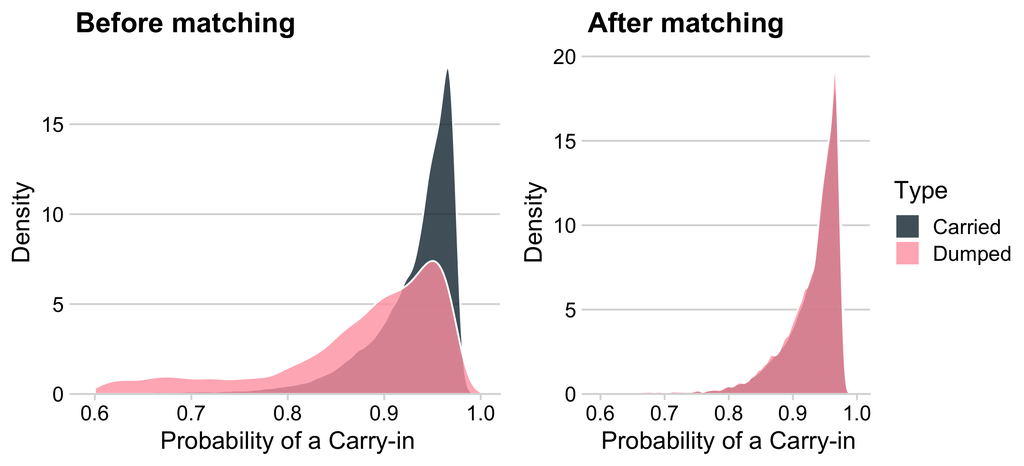

Figure 1: Density curves showing the probability of a carry-in before and after matching for all plays from the 2017 through 2019 seasons (277,661 entries) of the National Hockey League, using regular season games and 5v5 situations only.

## Results

#### Propensity score matching

With our propensity score model, the estimated ATT was `0.0209`. **Table 2** shows the estimated ATT’s for the three outcomes considered among the matched cohort:

**Table 2: Estimated ATT’s in matching cohort for the outcomes considered**

|  | Avg. xG for per 30s | Avg. xG against per 30s | Avg. Shots on Goal per 30s |
| --- | --- | --- | --- |
| Estimated ATT | 0.02095 | 0.000 | 0.2565 |

The estimated ATT’s in the table above represent the difference in the outcomes for an entry that was a carry-in (not a dump-in). Approximately, there is 1 extra goal produced every 50 carry-ins given that there are about 30 carry-ins per game per team. Additionally, xG against are not any worse after a carry-in. Of note, given the large number plays ( `n = 153,498` ), the standard errors were very small.

#### BART

Compared to propensity score matching, BART yielded a similar ATT estimate of `0.0205` . BART is able to identify heterogenous treatment effects across different groups. In other words, BART allows us to estimate the benefit of carrying it in for each variable. Comparing defensemen to forwards, we see that in the table below, it is approximately 23% more beneficial for a forward to carry it in:

|  | Avg. ATT | Std Error |
| --- | --- | --- |
| Forward | 0.0211 | 0.0000134 |
| Defenseman | 0.0171 | 0.0000296 |

There appears to be no association between Goals plus-minus per 60 minutes and position of entry player as shown in the figure below. The difference between carrying it in and dumping it appears to be the same for players of different skill level:

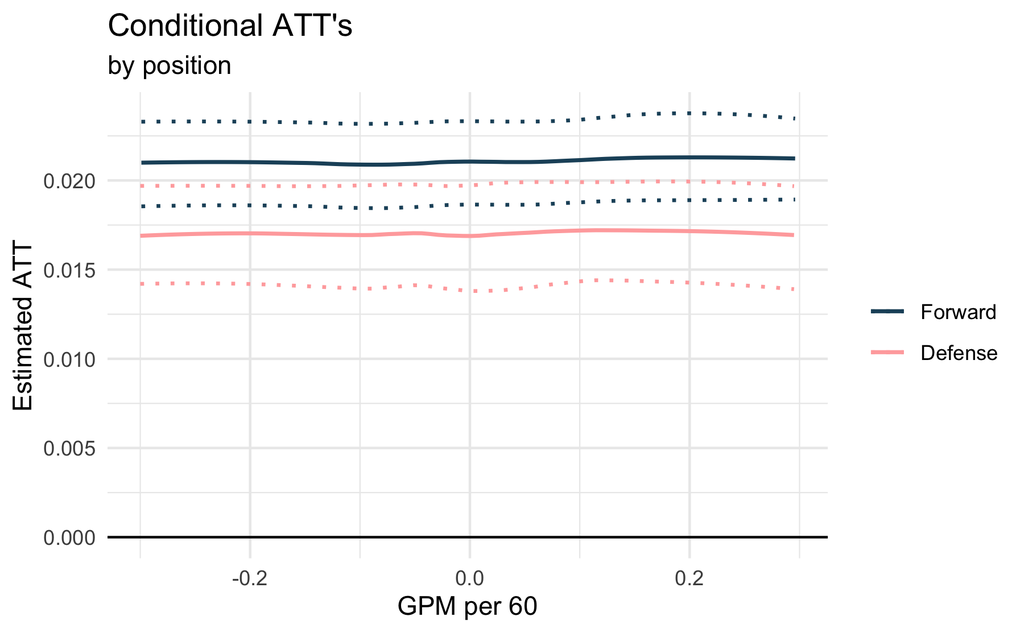

Figure 2: Conditional Average Treatment effect on the Treated (CATT) for entry player’s position. The solid lines represent the true treatment effect as it varies with X. The dotted lines represent the marginal 95% posterior intervals for the treatment effect at each X value from a treated observation.

In the figure below, there was also no observable difference between causal estimates by score differential, game seconds left or shift length. We see that the marginal 95% posterior intervals – represented by the dotted lines – cover the true CATT’s well. The exception is for `game_seconds` above 3000 seconds where no overlap exists:

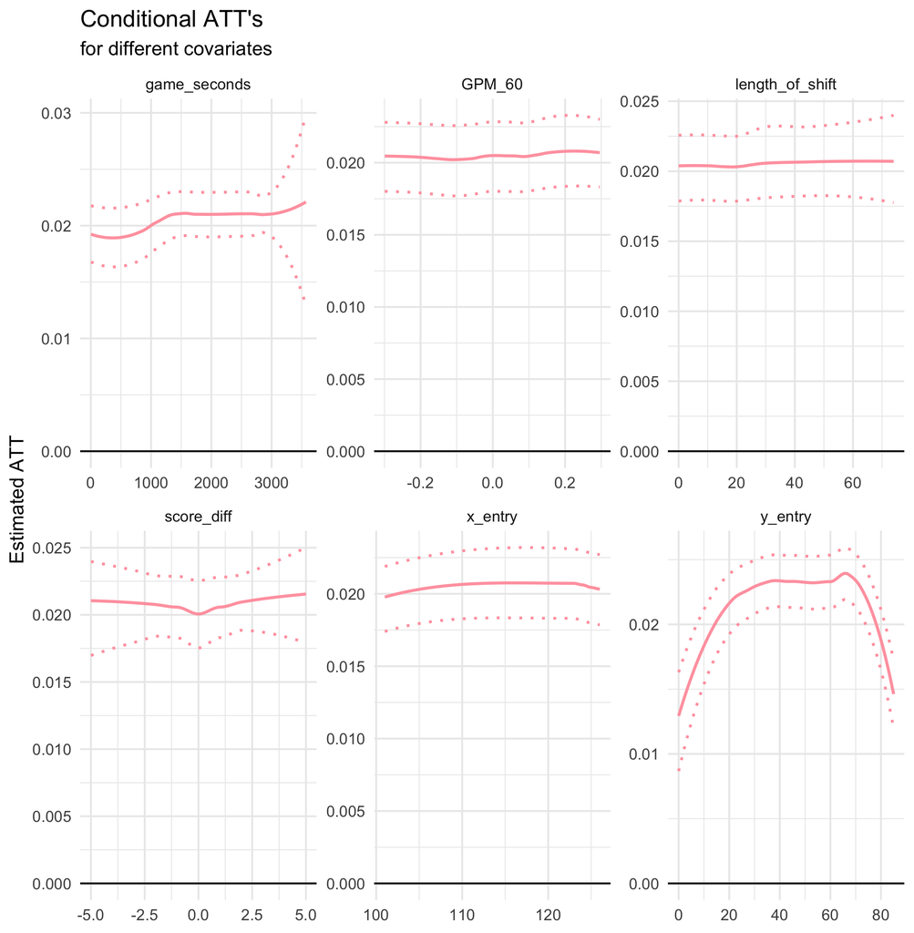

Figure 3: Conditional Average Treatment effect on the Treated (CATT) for different covariates. The solid lines represent the true treatment effect as it varies with X. The dotted lines represent the marginal 95% posterior intervals for the treatment effect at each X value from a treated observation.

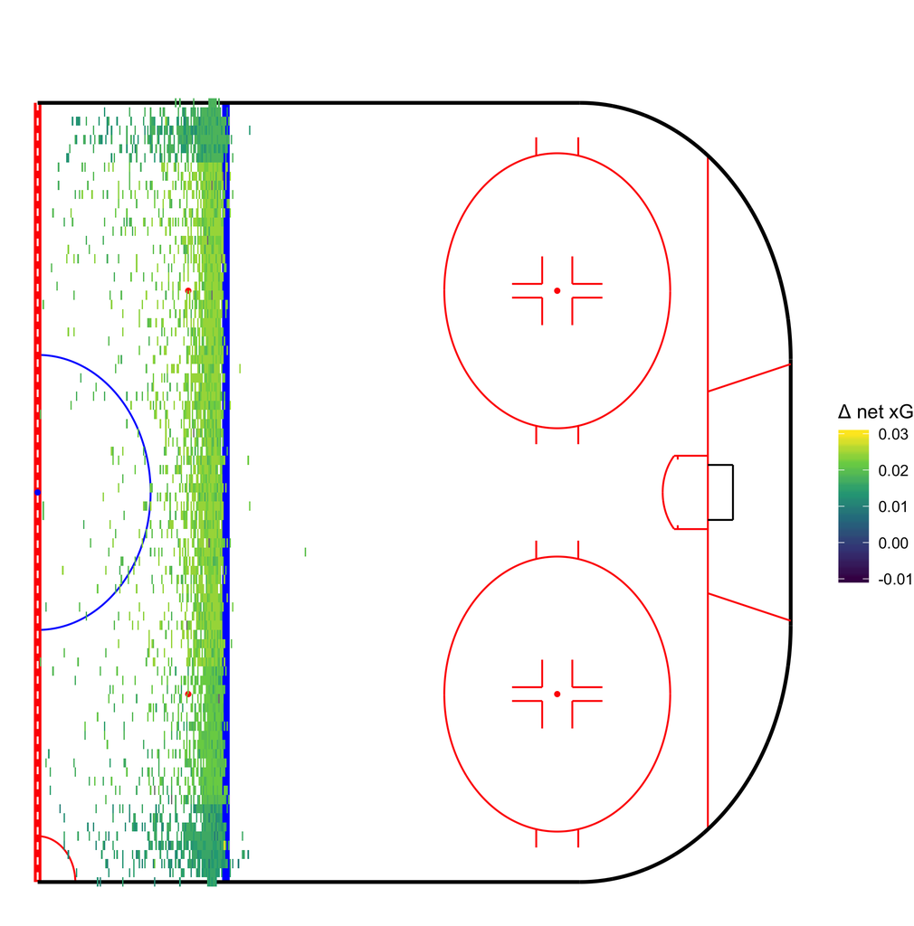

Figure 4: Spatial plot.

## Limitations

To produce meaningful inferences on zone entry decision-making, we considered many confounders such as score differential, time left on the clock, entry player skill and entry player location. One coufounder that we did not have access to is the location of all the other players on the ice, especially that of opposing players. It is our hope that in the future we can expand our study to include this important confounder and others that might be related to zone entry decision-making.

## Code and data

Although we cannot share the tracking data, our entire analysis plan is available on Github in our public repository. This includes publicly available data like the NHL pbp and Evolving-Hockey data as well as code for all of our data wrangling, analysis and visualizations.

Please consult https://github.com/asmae-toumi/zone-entries for the code, data, figures and relevant literature.

## Acknowledgments

Our thanks to Meghan Chayka, Neil Lane and the entire team at Stathletes for their tracking data and guidance. Thanks to Evolving-Hockey for providing NHL play-by-play data and their Goals Plus-Minus metric through their website: www.evolving-hockey.com.

## References

Please see `manuscripts` folder in https://github.com/asmae-toumi/zone-entries

## Reuse

Source code for this document is available at https://github.com/asmae-toumi/zone-entries.

## Corrections

If you see mistakes or want to suggest changes, please create an issue on the source repository.